# Task 2

Matthieu Huy

2023-01-30

```r
knitr::opts_chunk$set(echo = TRUE, message = FALSE, warning = FALSE)

library(tidyverse)
library(here)
library(lubridate)
library(AICcmodavg)
library(tidymodels)
library(cowplot)
library(equatiomatic)
```

## Read in data and observe any initial trends

This assignment uses hydrographic and biological data of the California Current System collected by [CalCOFI](https://calcofi.org/ccdata.html) to compare the performance of two competing linear regression models that predict oxygen saturation based on several physical and chemical variables, using AIC and cross validation.

Citation:  
CalCOFI data are available for use without restriction. Data downloaded from https://calcofi.org/ccdata.html. Accessed 1/30/2023.

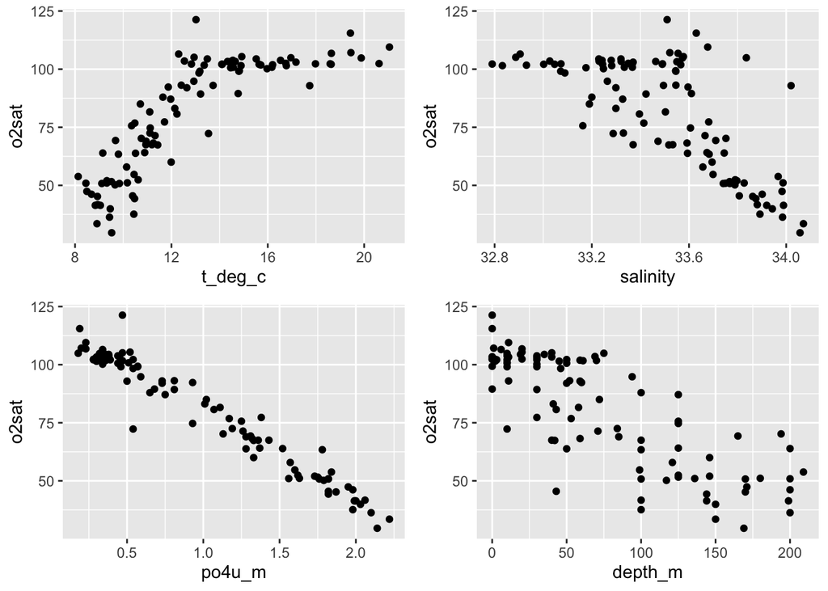

```r
data <- read.csv(here("data/calcofi_seawater_samples.csv"))

p1 <- ggplot(data = data,
                aes(x = t_deg_c,
                    y = o2sat)) +
  geom_point()
p2 <- ggplot(data = data,
                aes(x = salinity,
                    y = o2sat)) +
  geom_point()
p3 <- ggplot(data = data,
                aes(x = po4u_m,
                    y = o2sat)) +
  geom_point()
p4 <- ggplot(data = data,
                aes(x = depth_m,
                    y = o2sat)) +
  geom_point()

plot_grid(p1, p2, p3, p4)
```

From initial data observation, water temp and o2sat seem to be positively correlated, while phosphate concentration, salinity, and depth seem to be inversely correlated with o2sat.

## Create and compare two multiple linear regression models:

- Oxygen saturation as a function of water temperature, salinity, and phosphate concentration
- Oxygen saturation as a function of water temp, salinity, phosphate concentration, and depth.

## AIC and BIC comparison

```r
#create formulas for linear regression models
f1 <- o2sat ~ t_deg_c + salinity + po4u_m
f2 <- o2sat ~ t_deg_c + salinity + po4u_m + depth_m

#create linear regression models
mdl1 <- lm(f1, data = data)
mdl2 <- lm(f2, data = data)
summary(mdl1)
```

```
##
## Call:
## lm(formula = f1, data = data)
##
## Residuals:
##     Min      1Q  Median      3Q     Max
## -25.223  -2.349  -0.233   2.494  21.313
##
## Coefficients:
##             Estimate Std. Error t value Pr(>|t|)
## (Intercept) 195.7345    93.9380   2.084   0.0398 *
## t_deg_c      -0.4700     0.3902  -1.205   0.2313
## salinity     -2.1350     2.9344  -0.728   0.4686
## po4u_m      -38.4778     2.5207 -15.265   <2e-16 ***
## ---
## Signif. codes:  0 '***' 0.001 '**' 0.01 '*' 0.05 '.' 0.1 ' ' 1
##
## Residual standard error: 5.173 on 96 degrees of freedom
## Multiple R-squared:  0.9554, Adjusted R-squared:  0.954
## F-statistic: 685.5 on 3 and 96 DF,  p-value: < 2.2e-16
```

```r
summary(mdl2)
```

```
##
## Call:
## lm(formula = f2, data = data)
##
## Residuals:
##      Min       1Q   Median       3Q      Max
## -26.3023  -2.2828  -0.2479   2.1771  19.4459
##
## Coefficients:
##              Estimate Std. Error t value Pr(>|t|)
## (Intercept) 144.06686   95.36730   1.511   0.1342
## t_deg_c      -0.74981    0.40494  -1.852   0.0672 .
## salinity     -0.43945    2.98897  -0.147   0.8834
## po4u_m      -37.71159    2.50113 -15.078   <2e-16 ***
## depth_m      -0.03196    0.01497  -2.135   0.0354 *
## ---
## Signif. codes:  0 '***' 0.001 '**' 0.01 '*' 0.05 '.' 0.1 ' ' 1
##
## Residual standard error: 5.08 on 95 degrees of freedom
## Multiple R-squared:  0.9574, Adjusted R-squared:  0.9557
## F-statistic: 534.3 on 4 and 95 DF,  p-value: < 2.2e-16
```

```r
AICcmodavg::aictab(list(mdl1, mdl2)) #Delta AIC 2.42 in favor of model 2
```

```
##
## Model selection based on AICc:
##
##      K   AICc Delta_AICc AICcWt Cum.Wt      LL
## Mod2 6 616.60       0.00   0.77   0.77 -301.85
## Mod1 5 619.03       2.42   0.23   1.00 -304.19
```

```r
AICcmodavg::bictab(list(mdl1, mdl2)) #Delta BIC very small, very similar
```

```
##
## Model selection based on BIC:
##
##      K    BIC Delta_BIC BICWt Cum.Wt      LL
## Mod2 6 631.33      0.00  0.51   0.51 -301.85
## Mod1 5 631.41      0.08  0.49   1.00 -304.19
```

#### AIC Comparison:

Model 2 has a lower AIC (616.60) than model 1 (619.03), despite the penalty for having one more parameter. Delta AIC is 2.42, meaning there is fairly strong positive evidence in favor of model 2.

#### BIC Comparison:

The BIC for models 1 and 2 are nearly identical, with model 2’s (631.33) just slightly lower than model 1’s (631.41). Delta BIC is 0.08, meaning there is very weak evidence in favor of model 2. It makes sense that the delta BIC would be smaller than the delta AIC between the two models because BIC places a larger penalty on adding additional parameters when n is large.

## K-fold cross validation using for-loop

```r
#create function to calculate RMSE
calc_rmse <- function(x, y) {
  rmse <- (x - y)^2 %>% mean() %>% sqrt()
  return(rmse)
}

rmse_df <- data.frame()
```

```r
folds <- 10 # no. of folds for 10-fold corss-validation
folds_vec <- rep(1:folds, length.out = nrow(data)) #create folds vector

set.seed(42) #reproducible results for random sampling

data_folds <- data |>
  mutate(group = sample(folds_vec, #add column with randomly assigned fold numbers
                        size = n(), #size of sample
                        replace = FALSE)) #sample without replacement
#table(data_folds$group)

#for-loop method for k-fold cross validation
for(i in 1:folds) {
  kfold_test_df <- data_folds |> #create test dataframe
    filter(group == i)           #by selecting rows that match i = 1, 2, 3... or 10
  kfold_train_df <- data_folds |>#create training data frame
    filter(group != i)           #using rows that match other 9/10 folds

  kfold_lm1 <- lm(f1, data = kfold_train_df) #create model 1 based on training df
  kfold_lm2 <- lm(f2, data = kfold_train_df) #create model 2 based on training df

  kfold_pred_df <- kfold_test_df |> #create predictions data frame
    mutate(mdl1 = predict(kfold_lm1, kfold_test_df), #results from mdl1 predicting on test df
           mdl2 = predict(kfold_lm2, kfold_test_df)) #results from mdl2 predicting on test df
  kfold_rmse <- kfold_pred_df |> #create RMSE data frame from o2sat predictions
    summarize(rmse_mdl1 = calc_rmse(mdl1, o2sat),
              rmse_mdl2 = calc_rmse(mdl2, o2sat),
              test_gp = i)
  rmse_df <- bind_rows(rmse_df, kfold_rmse) #add results of kfold_rmse to empty rmse df
}

rmse_df
```

```
##    rmse_mdl1 rmse_mdl2 test_gp
## 1   8.859422  9.497512       1
## 2   5.305887  4.767567       2
## 3   3.347886  3.060239       3
## 4   4.170602  3.982465       4
## 5   7.672617  7.247790       5
## 6   3.892150  3.510024       6
## 7   5.553732  5.386614       7
## 8   4.039562  3.630306       8
## 9   3.132213  3.953219       9
## 10  3.791977  3.727486      10
```

```r
rmse_df |>
  summarize(mean_rmse_mdl1 = mean(rmse_mdl1),
            mean_rmse_mdl2 = mean(rmse_mdl2))
```

```
##   mean_rmse_mdl1 mean_rmse_mdl2
## 1       4.976605       4.876322
```

#### 10-fold cross-validation comparison of the two models:

Model 2 performs better than model 1 based on trying to minimize root-mean-squared-error, with a mean RMSE of 4.8763 compared to 4.9766 for model 1.

## Exploring another potential model

```r
f3 <- o2sat ~ po4u_m + depth_m

mdl3 <- lm(f3, data = data)
summary(mdl3)
```

```
##
## Call:
## lm(formula = f3, data = data)
##
## Residuals:
##     Min      1Q  Median      3Q     Max
## -25.203  -2.624  -0.386   2.550  21.084
##
## Coefficients:
##              Estimate Std. Error t value Pr(>|t|)
## (Intercept) 116.74438    0.95643 122.063   <2e-16 ***
## po4u_m      -35.16717    1.41122 -24.920   <2e-16 ***
## depth_m      -0.02513    0.01436  -1.751   0.0831 .
## ---
## Signif. codes:  0 '***' 0.001 '**' 0.01 '*' 0.05 '.' 0.1 ' ' 1
##
## Residual standard error: 5.175 on 97 degrees of freedom
## Multiple R-squared:  0.9549, Adjusted R-squared:  0.954
## F-statistic:  1027 on 2 and 97 DF,  p-value: < 2.2e-16
```

```r
AICcmodavg::aictab(list(mdl1, mdl2, mdl3))
```

```
##
## Model selection based on AICc:
##
##      K   AICc Delta_AICc AICcWt Cum.Wt      LL
## Mod2 6 616.60       0.00   0.55   0.55 -301.85
## Mod3 4 617.91       1.31   0.29   0.84 -304.75
## Mod1 5 619.03       2.42   0.16   1.00 -304.19
```

```r
AICcmodavg::bictab(list(mdl1, mdl2, mdl3))
```

```
##
## Model selection based on BIC:
##
##      K    BIC Delta_BIC BICWt Cum.Wt      LL
## Mod3 4 627.91      0.00  0.74   0.74 -304.75
## Mod2 6 631.33      3.42  0.13   0.87 -301.85
## Mod1 5 631.41      3.50  0.13   1.00 -304.19
```

Model 3 performs slightly worse than model 2 in the AIC comparison (delta AIC = -1.31), but much better in the BIC comparison (delta BIC = 3.42).

```r
rmse_df_mdl3 <- data.frame()

folds <- 10
folds_vec <- rep(1:folds, length.out = nrow(data))

set.seed(42)

data_folds <- data |>
  mutate(group = sample(folds_vec,
                        size = n(),
                        replace = FALSE))

for(i in 1:folds) {
  kfold_test_df <- data_folds |>
    filter(group == i)
  kfold_train_df <- data_folds |>
    filter(group != i)

  kfold_lm1 <- lm(f1, data = kfold_train_df)
  kfold_lm2 <- lm(f2, data = kfold_train_df)
  kfold_lm3 <- lm(f3, data = kfold_train_df) #create model 3 based on training df

  kfold_pred_df <- kfold_test_df |>
    mutate(mdl1 = predict(kfold_lm1, kfold_test_df),
           mdl2 = predict(kfold_lm2, kfold_test_df),
           mdl3 = predict(kfold_lm3, kfold_test_df)) #results from mdl3 predicting on test df
  kfold_rmse <- kfold_pred_df |>
    summarize(rmse_mdl1 = calc_rmse(mdl1, o2sat),
              rmse_mdl2 = calc_rmse(mdl2, o2sat),
              rmse_mdl3 = calc_rmse(mdl3, o2sat),
              test_gp = i)
  rmse_df_mdl3 <- bind_rows(rmse_df_mdl3, kfold_rmse)
}

rmse_df_mdl3
```

```
##    rmse_mdl1 rmse_mdl2 rmse_mdl3 test_gp
## 1   8.859422  9.497512  8.794559       1
## 2   5.305887  4.767567  5.195285       2
## 3   3.347886  3.060239  3.378504       3
## 4   4.170602  3.982465  3.859278       4
## 5   7.672617  7.247790  7.242098       5
## 6   3.892150  3.510024  3.784584       6
## 7   5.553732  5.386614  5.106633       7
## 8   4.039562  3.630306  3.849153       8
## 9   3.132213  3.953219  4.235945       9
## 10  3.791977  3.727486  4.189440      10
```

```r
rmse_df_mdl3 |>
  summarize(mean_rmse_mdl1 = mean(rmse_mdl1),
            mean_rmse_mdl2 = mean(rmse_mdl2),
            mean_rmse_mdl3 = mean(rmse_mdl3))
```

```
##   mean_rmse_mdl1 mean_rmse_mdl2 mean_rmse_mdl3
## 1       4.976605       4.876322       4.963548
```

Model 3 performs worse than model 2 in the cross validation test, with a mean RMSE of 4.9634 compared to 4.8763, but it performs better than model 1.

## Parameterize final model using the whole data set

AIC and cross validation both indicate model 2 as the best model, so we will use it as our final model.

```r
final_mdl <- lm(f2, data = data)
summary(final_mdl)
```

```
##
## Call:
## lm(formula = f2, data = data)
##
## Residuals:
##      Min       1Q   Median       3Q      Max
## -26.3023  -2.2828  -0.2479   2.1771  19.4459
##
## Coefficients:
##              Estimate Std. Error t value Pr(>|t|)
## (Intercept) 144.06686   95.36730   1.511   0.1342
## t_deg_c      -0.74981    0.40494  -1.852   0.0672 .
## salinity     -0.43945    2.98897  -0.147   0.8834
## po4u_m      -37.71159    2.50113 -15.078   <2e-16 ***
## depth_m      -0.03196    0.01497  -2.135   0.0354 *
## ---
## Signif. codes:  0 '***' 0.001 '**' 0.01 '*' 0.05 '.' 0.1 ' ' 1
##
## Residual standard error: 5.08 on 95 degrees of freedom
## Multiple R-squared:  0.9574, Adjusted R-squared:  0.9557
## F-statistic: 534.3 on 4 and 95 DF,  p-value: < 2.2e-16
```

### Final Model:

$$\begin{aligned}
\operatorname{\widehat{o2sat}} &= 144.07 -
0.75(\operatorname{t\_deg\_c}) - 0.44(\operatorname{salinity}) -
37.71(\operatorname{po4u\_m}) - 0.03(\operatorname{depth\_m})
\end{aligned}$$